# Example 1: House price forecast

Author: Gurakuqi Jurgen

The dataset houses-canada.csv includes 4 variables about a random selection of 546 houses sold in a Canadian city: price: Sale price of the house;

lotsize: Lot size of the property in square feet;

stories: Number of stories (floors) excluding basement;

gasheat: Does the house use gas for hot water heating?

First, we read the data, then we show 6 rows of the dataset to understand how the variables of the dataset are populated:

```r
house <- read.csv("houses-canada.csv")
head(house)
```

```
##   price lotsize stories gasheat
## 1 42000    5850       2      no
## 2 38500    4000       1      no
## 3 49500    3060       1      no
## 4 60500    6650       2      no
## 5 61000    6360       1      no
## 6 66000    4160       1      no
```

We also print the data to understand how the data is distributed and if some variables need to be factorized:

```r
summary(house)
```

```
##      price           lotsize         stories        gasheat
##  Min.   : 25000   Min.   : 1650   Min.   :1.000   Length:546
##  1st Qu.: 49125   1st Qu.: 3600   1st Qu.:1.000   Class :character
##  Median : 62000   Median : 4600   Median :2.000   Mode  :character
##  Mean   : 68122   Mean   : 5150   Mean   :1.808
##  3rd Qu.: 82000   3rd Qu.: 6360   3rd Qu.:2.000
##  Max.   :190000   Max.   :16200   Max.   :4.000
```

```r
table(house$stories)
```

```
##
##   1   2   3   4
## 227 238  40  41
```

As we can see, there are categorical variables which need to be transformed into factors:

```r
house$gasheat <- factor(house$gasheat)
house$stories <- factor(house$stories)
summary(house)
```

```
##      price           lotsize      stories gasheat
##  Min.   : 25000   Min.   : 1650   1:227   no :521
##  1st Qu.: 49125   1st Qu.: 3600   2:238   yes: 25
##  Median : 62000   Median : 4600   3: 40
##  Mean   : 68122   Mean   : 5150   4: 41
##  3rd Qu.: 82000   3rd Qu.: 6360
##  Max.   :190000   Max.   :16200
```

We try now to fit a possible model:

```r
mod1 <- lm(price ~ lotsize + stories + gasheat, data = house)
summary(mod1)
```

```
##
## Call:
## lm(formula = price ~ lotsize + stories + gasheat, data = house)
##
## Residuals:
##    Min     1Q Median     3Q    Max
## -56592 -12855  -2008   8831  96883
##
## Coefficients:
##              Estimate Std. Error t value Pr(>|t|)
## (Intercept) 2.647e+04  2.533e+03  10.450  < 2e-16 ***
## lotsize     6.190e+00  4.065e-01  15.227  < 2e-16 ***
## stories2    1.144e+04  1.881e+03   6.084 2.22e-09 ***
## stories3    2.072e+04  3.458e+03   5.991 3.81e-09 ***
## stories4    3.624e+04  3.448e+03  10.508  < 2e-16 ***
## gasheatyes  1.192e+04  4.140e+03   2.879  0.00415 **
## ---
## Signif. codes:  0 '***' 0.001 '**' 0.01 '*' 0.05 '.' 0.1 ' ' 1
##
## Residual standard error: 20100 on 540 degrees of freedom
## Multiple R-squared:  0.4387, Adjusted R-squared:  0.4336
## F-statistic: 84.43 on 5 and 540 DF,  p-value: < 2.2e-16
```

As we can see in the summary, all the predictors, except gasheat are strongly significant and positively related to the response. Gasheat is also positively related to price, but just significant. Also the intercept, which includes stories1, is strongly significant and positively related to the response. The $R^2$ is *44%*, and the adjusted $R^2$ is *43%*.

Now, we must validate the model assumptions through the residual analysis and the normal probability plot analysis:

```r
library(car)
```

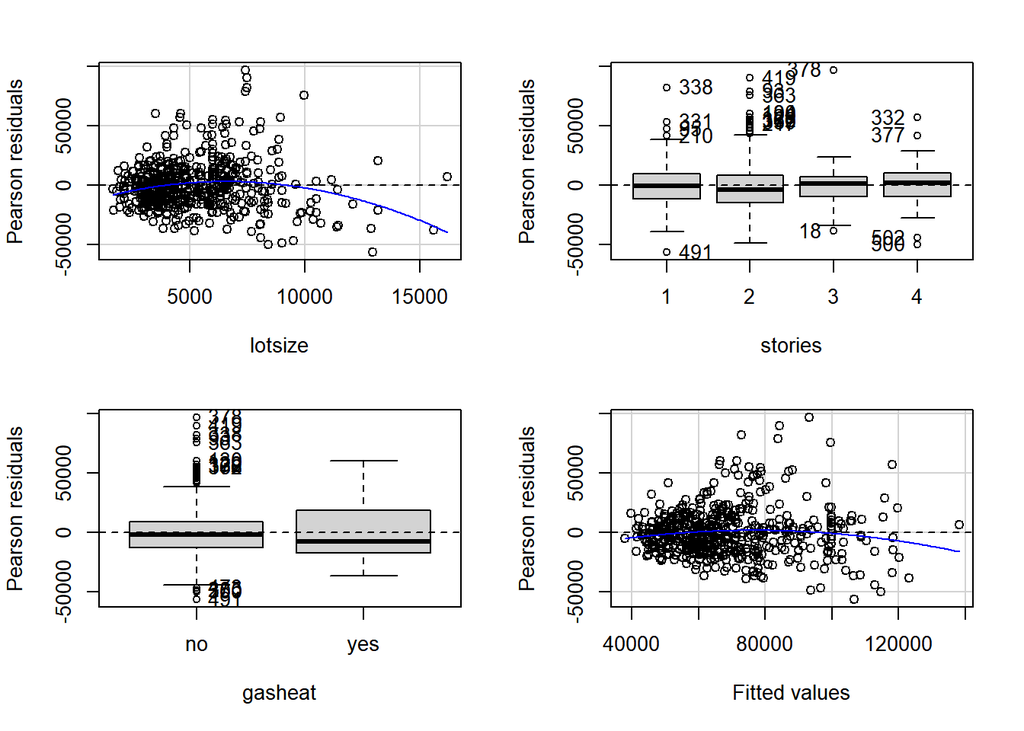

```
##            Test stat Pr(>|Test stat|)
## lotsize      -4.5108         7.93e-06 ***
## stories
## gasheat
## Tukey test   -2.4278          0.01519 *
## ---
## Signif. codes:  0 '***' 0.001 '**' 0.01 '*' 0.05 '.' 0.1 ' ' 1
```

```r
residualPlots(mod1)
```

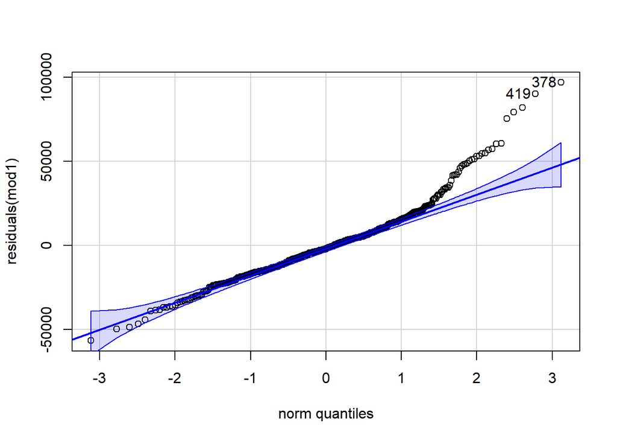

```
## [1] 378 419
```

```r
qqPlot(residuals(mod1))
```

We can see that:

- The qqplot shows a strong departure from the normality on the right.
- The residuals show a lot of outliers for gasheat and stories, and some patterns on the lotsize and on the fitted values. The problems are also confirmed by the weakly significant Tukey test, and by the strongly significant test statistic of lotsize, so something is missing.

We can also check the effect plots to check the relation between the predictors and the response, and confirm what we have seen in the summary:

```r
library(effects)
```

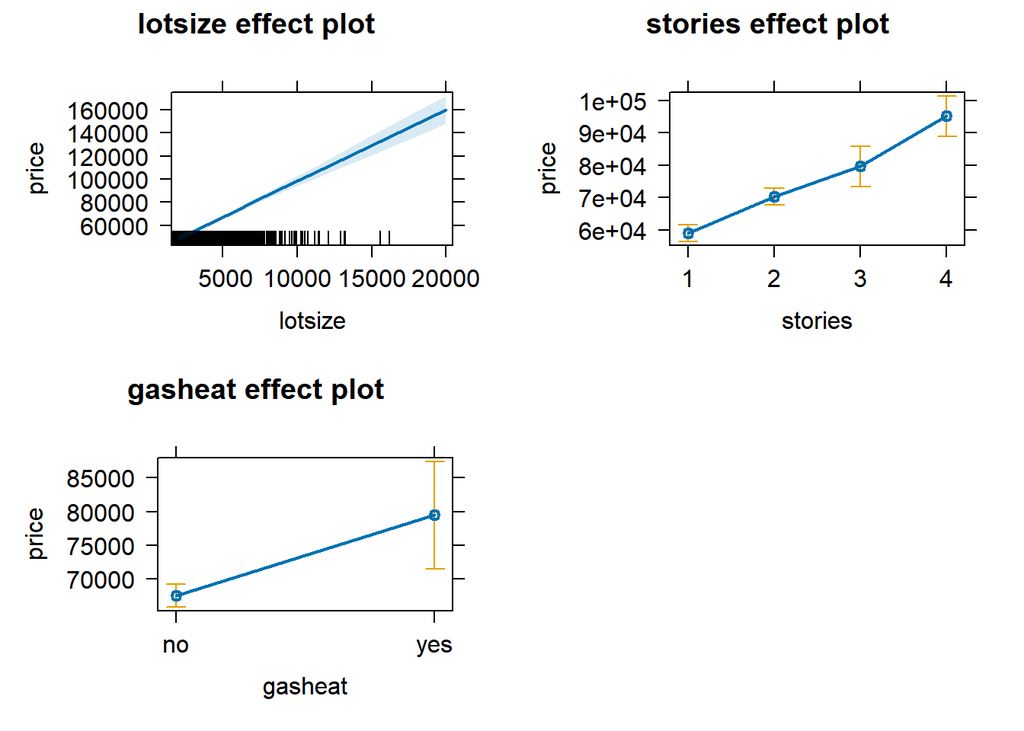

```r
plot(allEffects(mod1))
```

Every effect plot confirms what we have previously said about the predictors in the summary:

- Lotsize causes strong increments in the price according to its increase.
- Stories causes great changes in the price according to it’s value change.
- Gasheat causes a visible increase when changing from no to yes.

We check for the presence of possible *influential points*:

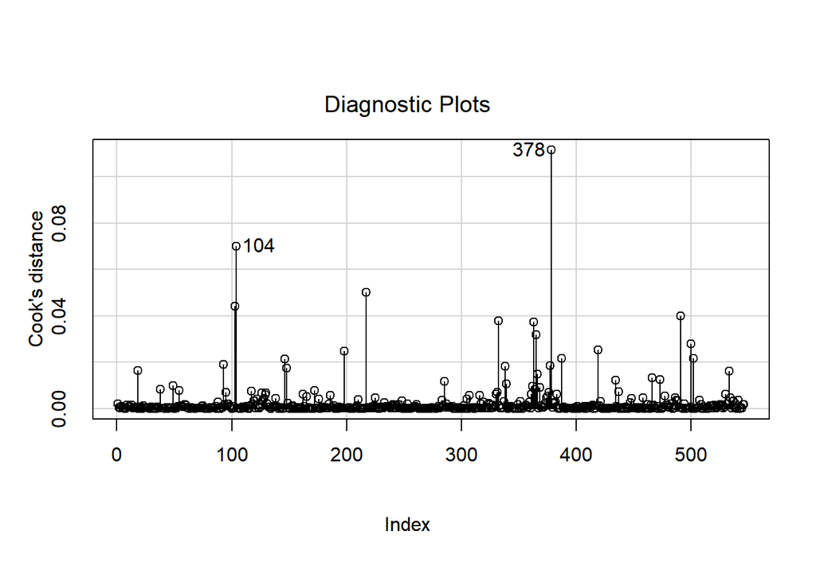

```r
influenceIndexPlot(mod1, vars = "Cook")
```

Also we check for the presence of multicollinearities:

```r
vif(mod1)
```

```
##             GVIF Df GVIF^(1/(2*Df))
## lotsize 1.048167  1        1.023800
## stories 1.061188  3        1.009947
## gasheat 1.012554  1        1.006258
```

The possible multicollinearities are indicated for values near to or higher than 5, and strong multicollinearities are inidicated for values higher than 10, but in this case none of the values shows problems, so there are not multicollinarities.

A last check we do is about the values that this model can return, considering that a money response should not assume negative values:

```r
summary(fitted(mod1))
```

```
##    Min. 1st Qu.  Median    Mean 3rd Qu.    Max.
##   37834   55270   64193   68122   77537  138188
```

This model does not show problems about negative responses, so we do not need to fit a logarithmic version of it.

We could try to improve our model with the introduction of an interaction term:

```r
mod2 <- update(mod1, . ~ . + stories * lotsize)
summary(mod2)
```

```
##
## Call:
## lm(formula = price ~ lotsize + stories + gasheat + lotsize:stories,
##     data = house)
##
## Residuals:
##    Min     1Q Median     3Q    Max
## -52452 -12598  -2086   8981  94228
##
## Coefficients:
##                   Estimate Std. Error t value Pr(>|t|)
## (Intercept)      3.192e+04  3.372e+03   9.467  < 2e-16 ***
## lotsize          5.157e+00  5.860e-01   8.800  < 2e-16 ***
## stories2         1.647e+03  4.650e+03   0.354  0.72339
## stories3         8.455e+03  9.902e+03   0.854  0.39355
## stories4         2.513e+04  1.782e+04   1.410  0.15918
## gasheatyes       1.230e+04  4.134e+03   2.975  0.00306 **
## lotsize:stories2 1.941e+00  8.484e-01   2.288  0.02252 *
## lotsize:stories3 2.309e+00  1.747e+00   1.322  0.18680
## lotsize:stories4 1.903e+00  2.711e+00   0.702  0.48301
## ---
## Signif. codes:  0 '***' 0.001 '**' 0.01 '*' 0.05 '.' 0.1 ' ' 1
##
## Residual standard error: 20040 on 537 degrees of freedom
## Multiple R-squared:  0.445,  Adjusted R-squared:  0.4367
## F-statistic: 53.81 on 8 and 537 DF,  p-value: < 2.2e-16
```

As we can see in the summary:

- **lotsize** is *strongly* significant, and *positively* related to the response.
- **stories** has become *not* significant, and it’s *positively* related to the response.
- **gasheat** has mantained it’s significance and positive relation with price.
- The interaction **lotsize/stories** is *weakly* significant for stories 2, and not significant for 3 and 4, whereas the 1 is included in the intercept, which has remained strongly significant.
- Stories alone seems to be not significant, but yet positively related to price.
- The intercept, which includes stories1 and stories1:lotsize, is strongly significant and positively related to the response.
- The $R^2$ is *45%*, and the adjusted $R^2$ is *44%*, which are better then those of the previous model, but not that much.

Again, we check the residuals and the normal probability plot:

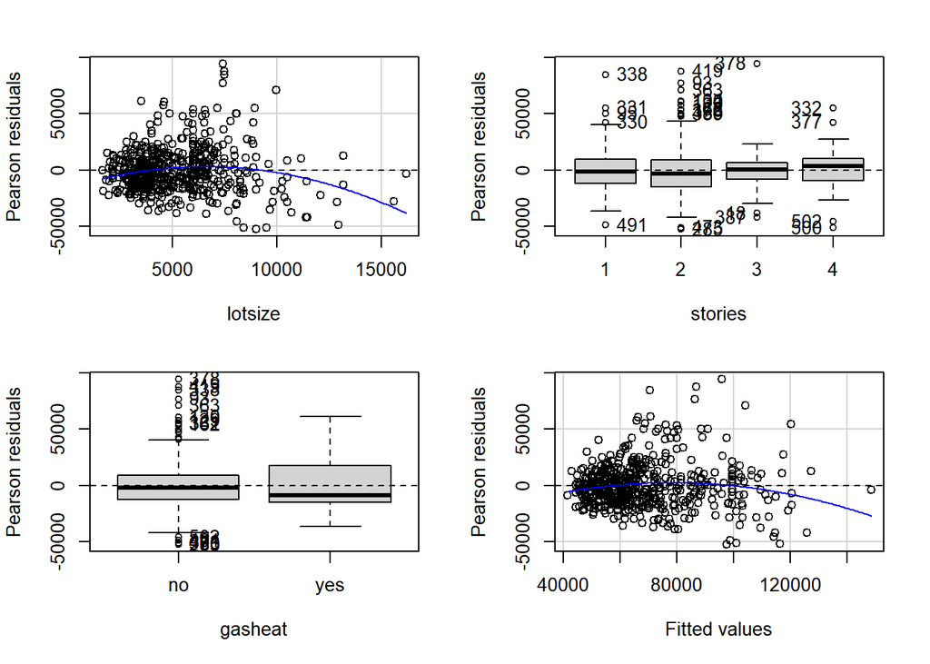

```
##            Test stat Pr(>|Test stat|)
## lotsize      -4.4174        1.209e-05 ***
## stories
## gasheat
## Tukey test   -3.6371        0.0002757 ***
## ---
## Signif. codes:  0 '***' 0.001 '**' 0.01 '*' 0.05 '.' 0.1 ' ' 1
```

```r
residualPlots(mod2)
```

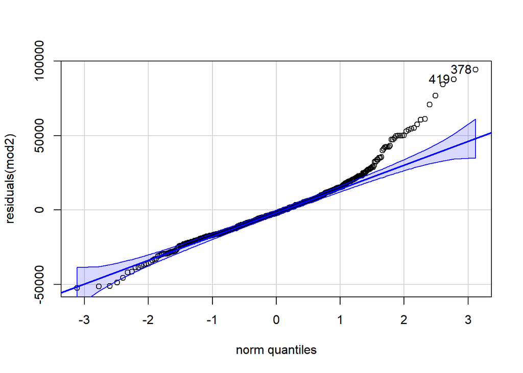

```
## [1] 378 419
```

```r
qqPlot(residuals(mod2))
```

Yet, the qqplot shows a strong departure from the normality, and the residuals are not good again. Also, this time the Tukey test has got worse then before.

We check again the effect plots:

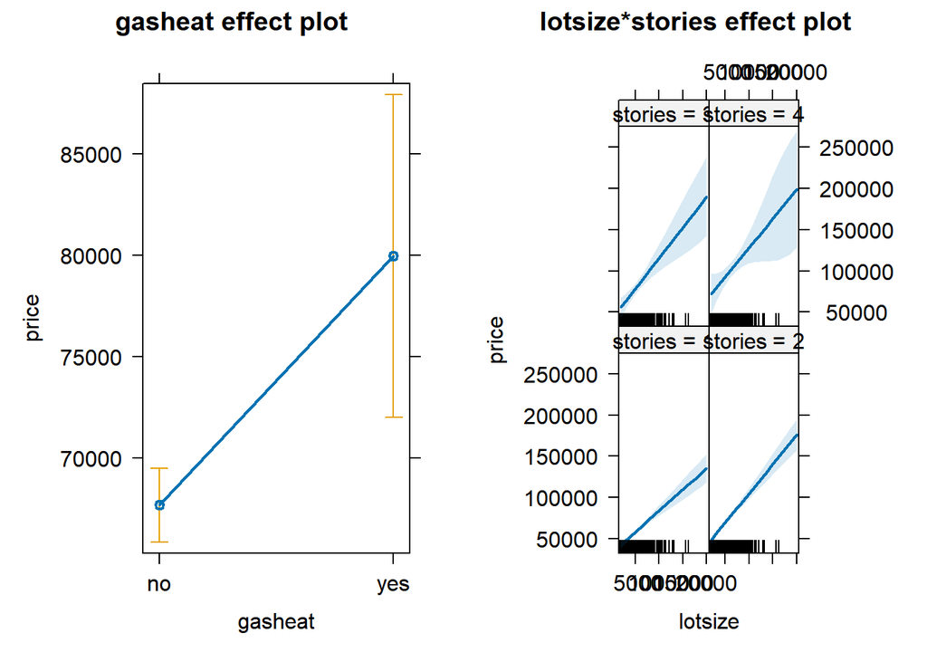

```r
plot(allEffects(mod2))
```

Each plot confirms the previous results shown in the summary:

- Gasheat is significant, as it rises the price by changing from No to yes, but not in a concrete way.
- The inreaction does not show clear increases for stories 3 and 4, but shows some light increases for 1 and 2.

We can try also a last model using other interactions:

```r
mod3 <- update(mod2, . ~ . + gasheat * lotsize)
summary(mod3)
```

```
##
## Call:
## lm(formula = price ~ lotsize + stories + gasheat + lotsize:stories +
##     lotsize:gasheat, data = house)
##
## Residuals:
##    Min     1Q Median     3Q    Max
## -52424 -12604  -2108   8952  94286
##
## Coefficients:
##                     Estimate Std. Error t value Pr(>|t|)
## (Intercept)        3.205e+04  3.442e+03   9.311   <2e-16 ***
## lotsize            5.131e+00  6.024e-01   8.518   <2e-16 ***
## stories2           1.569e+03  4.673e+03   0.336   0.7373
## stories3           8.511e+03  9.915e+03   0.858   0.3911
## stories4           2.500e+04  1.785e+04   1.401   0.1619
## gasheatyes         1.060e+04  1.003e+04   1.057   0.2909
## lotsize:stories2   1.958e+00  8.542e-01   2.293   0.0222 *
## lotsize:stories3   2.302e+00  1.749e+00   1.316   0.1886
## lotsize:stories4   1.928e+00  2.716e+00   0.710   0.4781
## lotsize:gasheatyes 3.353e-01  1.804e+00   0.186   0.8526
## ---
## Signif. codes:  0 '***' 0.001 '**' 0.01 '*' 0.05 '.' 0.1 ' ' 1
##
## Residual standard error: 20060 on 536 degrees of freedom
## Multiple R-squared:  0.445,  Adjusted R-squared:  0.4357
## F-statistic: 47.75 on 9 and 536 DF,  p-value: < 2.2e-16
```

Again, we check the residuals and the normal probability plot:

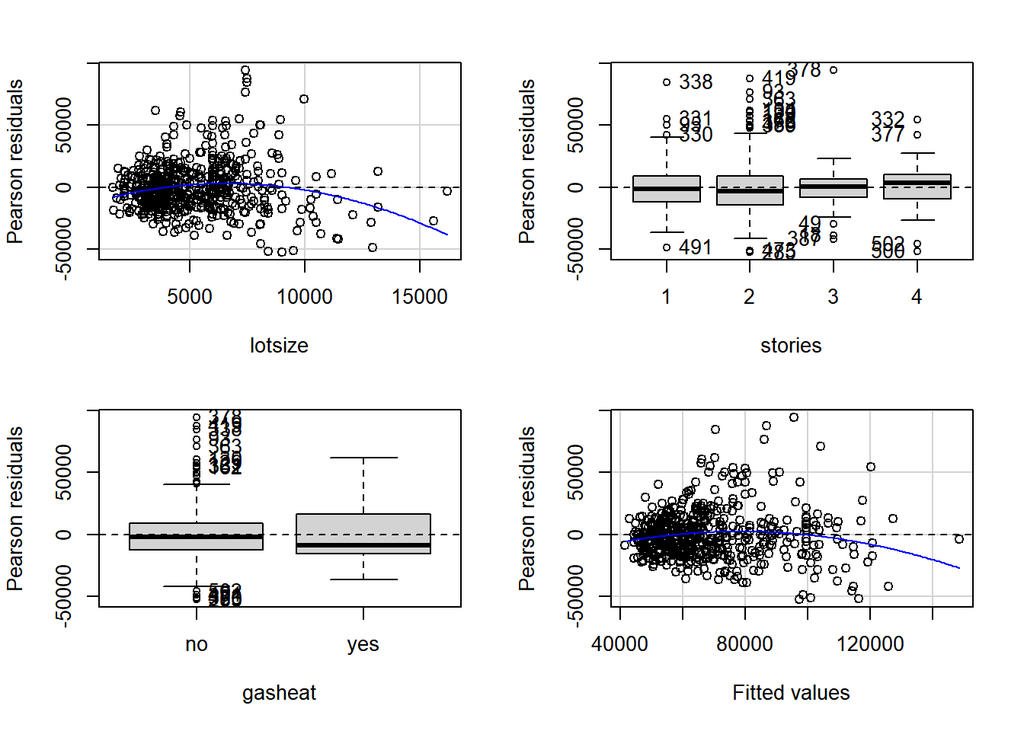

```
##            Test stat Pr(>|Test stat|)
## lotsize      -4.4302        1.142e-05 ***
## stories
## gasheat
## Tukey test   -3.7439        0.0001812 ***
## ---
## Signif. codes:  0 '***' 0.001 '**' 0.01 '*' 0.05 '.' 0.1 ' ' 1
```

```r
residualPlots(mod3)
```

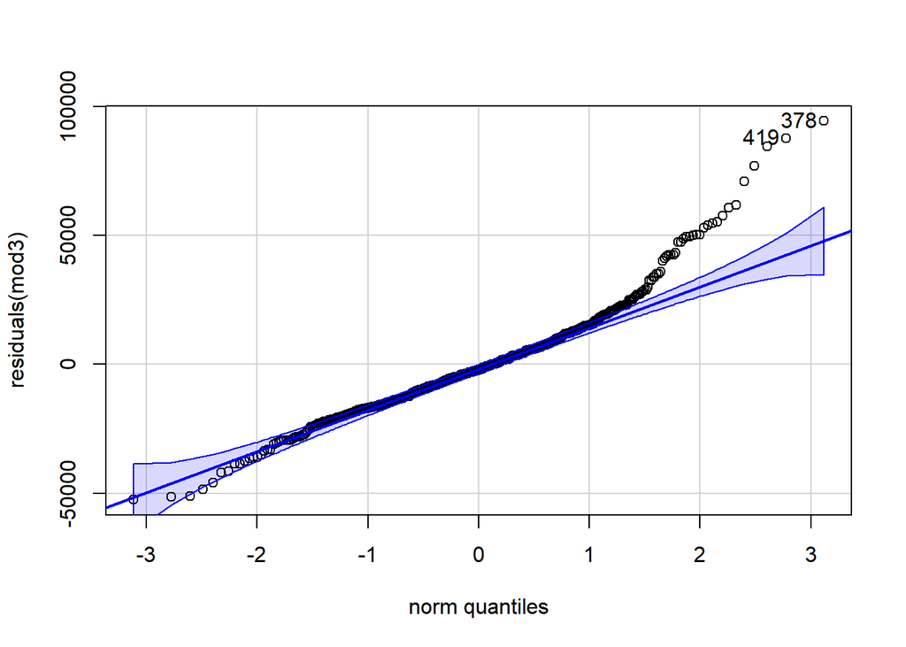

```
## [1] 378 419
```

```r
qqPlot(residuals(mod3))
```

The qqplot shows again a strong departure from the normality, and the residuals are not good. Also here the test significance for lotsize and the Tukey test are both strongly significant.

We check again the effect plots:

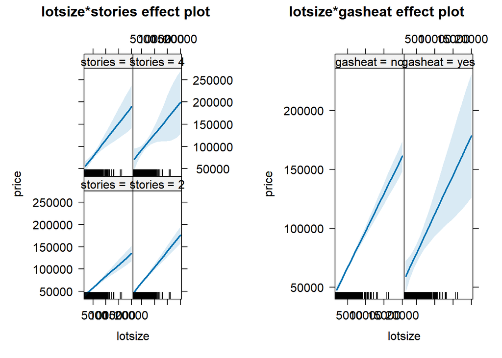

```r
plot(allEffects(mod3))
```

```r
pr <- predict(mod1,
              newdata = data.frame(gasheat = "yes",
                                   stories = "1",
                                   lotsize = 3000),
              se.fit = TRUE)
ci <- pr$fit + c(-1, 1) * qnorm(0.975) * pr$se
pr$fit
```

```
##        1
## 56958.75
```

```r
ci
```

```
## [1] 48460.82 65456.67
```

```r
pr <- predict(mod1,
              newdata = data.frame(gasheat = "no",
                                   stories = "2",
                                   lotsize = 3000),
              se.fit = TRUE)
ci <- pr$fit + c(-1, 1) * qnorm(0.975) * pr$se
pr$fit
```

```
##        1
## 56481.73
```

```r
ci
```

```
## [1] 53532.60 59430.87
```

```r
pr <- predict(mod1,
              newdata = data.frame(gasheat = "yes",
                                   stories = "4",
                                   lotsize = 3000),
              se.fit = TRUE)
ci <- pr$fit + c(-1, 1) * qnorm(0.975) * pr$se
pr$fit
```

```
##        1
## 93194.24
```

```r
ci
```

```
## [1]  82620.27 103768.22
```

```r
pr <- predict(mod1,
              newdata = data.frame(gasheat = "yes",
                                   stories = "1",
                                   lotsize = 6000),
              se.fit = TRUE)
ci <- pr$fit + c(-1, 1) * qnorm(0.975) * pr$se
pr$fit
```

```
##        1
## 75528.46
```

```r
ci
```

```
## [1] 67224.69 83832.23
```